# Sentiment reliability — can we run one cheap model at scale?

The roster ⑦ notebook established sentiment is *consistent* (within-model α 0.94) but only *moderately* agreed across models (panel α 0.64). This notebook asks the three questions that actually decide the production model choice:

1. **Where does each model sit?** Models differ systematically in how positive they are — so the choice of production model shifts the measured 'helped' rate.
2. **Where do models disagree?** The 0.64 α is real, but is it on the *effectiveness direction* (helped vs hurt) or the fuzzy *neutral boundary*? That decides whether the disagreement matters.
3. **Is one cheap model stable enough at scale?** DeepSeek Flash (the candidate) over 500 pairs × 5 repeats — item-level *and* aggregate.

*All against Polina (116 human labels) as a screen — she shares the prompt rubric, so this is agreement, not correctness; the permutation null is the separate is-it-drug-conditional check.*

*(loaded — 22 models × 116 (post,drug) pairs × 3 repeats; Polina reference 116 labels; production candidate = deepseek-v4-flash)*

## 1. Cross-model distribution — DeepSeek Flash is a *conservative* caller

The first thing that matters for a production switch: models don't just disagree at the margin, they sit at systematically different positive rates. Whichever model you pick sets the absolute 'helped' level, so its numbers aren't comparable to another model's.

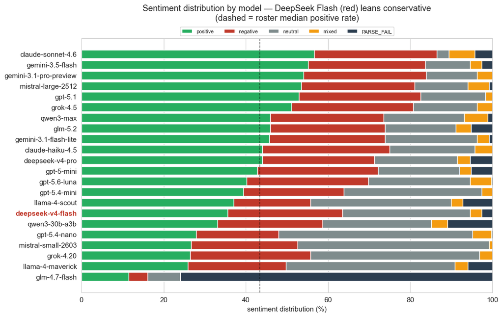

**DeepSeek Flash: 36% positive (roster median 43%), 31% neutral, 3% parse-fail** — it sits in the *cautious* cluster (less positive, more neutral), well below the frontier models (Sonnet 57%, Gemini-Pro 54%). **Consequence:** switching production from a Sonnet-based pipeline to DeepSeek Flash drops the measured positive rate ~20 points on identical posts. That's fine *if one model is held fixed across the whole corpus* (relative comparisons stay valid) — but its absolute rates are NOT comparable to the Sonnet-based published numbers. Conservatism is the SAFE direction re: the positive over-call concern.

## 2. Between-model structure — the disagreement is the neutral boundary, not direction

Panel α 0.64 is genuine (a clean 4-class label, no Jaccard artifact). But *where* models split decides whether it matters: a `positive↔negative` flip corrupts the effectiveness call; a `neutral↔weak-positive` flip is just granularity on the fuzzy middle.

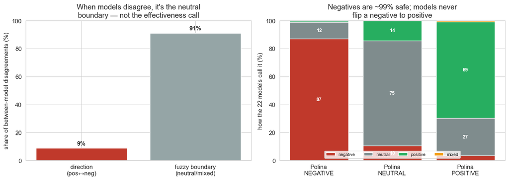

## 3. Within-model stability at scale — DeepSeek Flash, 500 pairs × 5 runs

The production question: at temperature 0, does one cheap model return the same answer run-to-run? Item-level and aggregate give *different* answers, and both matter.

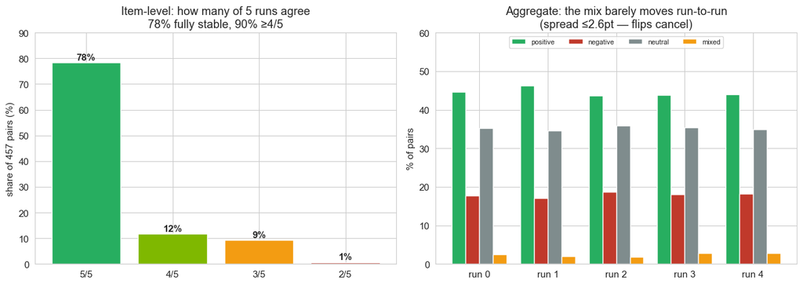

- **Item-level: moderate.** 78% of pairs identical across all 5 runs, 89% mean pairwise agreement — so ~11% of individual calls wobble at temp 0 (plausibly MoE backend nondeterminism).

- **The wobble is the fuzzy boundary, not the call:** of 99 unstable pairs, only **7 (1.5% of all pairs)** ever flip pos↔neg. The 'did it help' call is stable on ~98.5% of pairs.

- **Aggregate: rock-stable.** Positive stays within **2.6pt** across the 5 runs (negative 1.5pt, neutral 1.2pt) — the item flips cancel out.

## 4. Verdict — how to run it

1. **Fine for aggregate rates (what clustering consumes).** The distribution is stable to ~2 points run-to-run and the effectiveness *direction* is stable on ~98% of posts. This is the level that feeds clustering.

3. **Hold ONE model fixed across the whole corpus.** Its absolute positive rate is ~20pt below the frontier models (§1), so never mix models or compare to Sonnet-based numbers.

4. **Cluster on DIRECTION (helped / no-effect / hurt), not the 4-class or a continuous score.** Both the between-model 0.64 α (§2, 91% neutral-boundary) and the within-model wobble (§3, 93% neutral-boundary) collapse to ~1-2% once you binarize — the fragility is entirely in the neutral boundary.

**Still separate:** everything here is temp-0 variance and agreement-with-Polina, not *correctness*. Whether sentiment is drug-conditional at all is the **permutation null** (⑦ §5), still the highest-value open check before a large spend.

## Limitations

- **Polina is a screen, not truth** — 116 labels, and her codebook was lifted from the pipeline prompt, so agreement measures spec-compliance, not correctness. Her `neutral` set is ~5 items, so that column is thin.
- **Two different samples.** §1–2 use the 116-pair Polina set; §3 uses a larger 500-pair set (personal-use-first from the 300 IRR frame), which has a different base rate — so compare *stability* across sections, not absolute levels (§3 positive 44% vs §1 36% is sample composition, not a model change).
- **Within-model wobble is temp-0 run-to-run variance**, likely MoE backend nondeterminism — it says nothing about whether a call is *right*. Correctness is the permutation-null / vs-gold question, out of scope here.
- **Distribution ≠ effectiveness.** A model's positive rate reflects its calibration + the sample, not ground-truth drug efficacy. Not medical advice.

**Provenance**

| item | value |
| --- | --- |
| roster run | 22 models × 116 pairs × 3 |
| candidate | deepseek-v4-flash |
| stability run | 500 pairs × 5 (temp 0) |
| reference | human_coder_a (Polina), screen only |
| metric | distribution + disagreement structure + within-model stability |
| skill | research-assistant v2 |

Measures sentiment reliability against a human screen, not treatment effects. Not medical advice.